# 商务大数据课程大作业 —— Indeed 员工评论数据分析

```python
import pandas as pd
import numpy as np
import matplotlib.dates as mdates    #处理日期
import matplotlib.pyplot as plt

from collections import Counter
import time
import datetime
import math
```

## 抓取美国2000多家上市公司在Indeed员工评论平台的评论数据；该报告使用一半的数据，即使用一千多家公司数据进行分析

```python
data = pd.read_csv('indeed_really_1900.csv')
```

**数据集变量信息，包括列名，列名解释单独给出，每个公司对应一个company_id，未给出具体公司名称**

```python
data.info()
```

```
<class 'pandas.core.frame.DataFrame'>
RangeIndex: 1034508 entries, 0 to 1034507
Data columns (total 21 columns):
 #   Column                          Non-Null Count    Dtype
---  ------                          --------------    -----
 0   index                           1034508 non-null  int64
 1   company_id                      1034508 non-null  object
 2   overall_rating                  1034508 non-null  int64
 3   compensation_benefits_rating    1034508 non-null  int64
 4   culture_value_rating            1034508 non-null  int64
 5   jobSecurity_advancement_rating  1034508 non-null  int64
 6   management_rating               1034508 non-null  int64
 7   work_life_balance_rating        1034508 non-null  int64
 8   is_currentEmployee              1034508 non-null  bool
 9   helpful                         1034508 non-null  int64
 10  unhelpful                       1034508 non-null  int64
 11  job_title                       1033936 non-null  object
 12  location                        1034134 non-null  object
 13  job_title_filter_link           1034508 non-null  object
 14  redacted                        1034508 non-null  bool
 15  title                           1032414 non-null  object
 16  cons                            1032398 non-null  object
 17  pros                            1033560 non-null  object
 18  text                            1034503 non-null  object
 19  submission_date                 1034508 non-null  object
 20  tweet_auto_fill_text            1034508 non-null  object
dtypes: bool(2), int64(9), object(10)
memory usage: 151.9+ MB
```

```python
data.describe()
```

|  | index | overall_rating | compensation_benefits_rating | culture_value_rating | jobSecurity_advancement_rating | management_rating | work_life_balance_rating | helpful | unhelpful |
| --- | --- | --- | --- | --- | --- | --- | --- | --- | --- |
| count | 1.034508e+06 | 1.034508e+06 | 1.034508e+06 | 1.034508e+06 | 1.034508e+06 | 1.034508e+06 | 1.034508e+06 | 1.034508e+06 | 1.034508e+06 |
| mean | 3.667622e+04 | 3.653257e+00 | 3.127984e+00 | 3.154378e+00 | 2.919509e+00 | 2.989391e+00 | 3.230067e+00 | 2.282529e+00 | 7.556887e-01 |
| std | 3.106355e+04 | 1.235085e+00 | 1.590456e+00 | 1.625477e+00 | 1.595120e+00 | 1.623326e+00 | 1.582713e+00 | 5.914281e+00 | 2.631211e+00 |
| min | 0.000000e+00 | 1.000000e+00 | 0.000000e+00 | 0.000000e+00 | 0.000000e+00 | 0.000000e+00 | 0.000000e+00 | 0.000000e+00 | 0.000000e+00 |
| 25% | 1.332500e+04 | 3.000000e+00 | 2.000000e+00 | 2.000000e+00 | 2.000000e+00 | 2.000000e+00 | 2.000000e+00 | 0.000000e+00 | 0.000000e+00 |
| 50% | 2.875600e+04 | 4.000000e+00 | 3.000000e+00 | 3.000000e+00 | 3.000000e+00 | 3.000000e+00 | 4.000000e+00 | 1.000000e+00 | 0.000000e+00 |
| 75% | 5.080425e+04 | 5.000000e+00 | 5.000000e+00 | 5.000000e+00 | 4.000000e+00 | 4.000000e+00 | 5.000000e+00 | 2.000000e+00 | 1.000000e+00 |
| max | 1.494390e+05 | 5.000000e+00 | 5.000000e+00 | 5.000000e+00 | 5.000000e+00 | 5.000000e+00 | 5.000000e+00 | 5.140000e+02 | 9.800000e+02 |

```python
data.head()
```

|  | index | company_id | overall_rating | compensation_benefits_rating | culture_value_rating | jobSecurity_advancement_rating | management_rating | work_life_balance_rating | is_currentEmployee | helpful | ... | job_title | location | job_title_filter_link | redacted | title | cons | pros | text | submission_date | tweet_auto_fill_text |
| --- | --- | --- | --- | --- | --- | --- | --- | --- | --- | --- | --- | --- | --- | --- | --- | --- | --- | --- | --- | --- | --- |
| 0 | 0 | E1000496 | 5 | 5 | 5 | 5 | 5 | 5 | True | 0 | ... | Worker | Bloomfield, NM | MISS | False | Hard but fun work with flexible hours | MISS | MISS | The job requires you to go to different rent h... | October 29, 2019 | Parnell review on #indeedjobs: Hard but fun wo... |
| 1 | 1 | E1000496 | 2 | 1 | 1 | 1 | 1 | 3 | False | 0 | ... | Assistant to chef | Cork, C | /cmp/Parnell/reviews?fjobtitle=Assistant+Chef | False | I had more responsiblity here than in the Rob Roy | MISS | MISS | it was a bigger kitchen with just the chef and... | December 30, 2014 | Parnell review on #indeedjobs: I had more resp... |
| 2 | 2 | E10008 | 5 | 4 | 5 | 5 | 5 | 4 | True | 0 | ... | NaN | Nashville, TN | MISS | False | Great company culture, willing to make changes... | MISS | MISS | Overall, this is a great company to work for. ... | July 5, 2020 | HealthStream review on #indeedjobs: Great comp... |
| 3 | 3 | E10008 | 5 | 5 | 5 | 5 | 5 | 5 | False | 0 | ... | Interviewer | Nashville, TN | /cmp/Healthstream/reviews?fjobtitle=Interviewer | False | Healthstream is family | MISS | I had a sense of purpose working at Healthstream. | Healthstream was an extended family workplace.... | April 21, 2020 | HealthStream review on #indeedjobs: Healthstre... |
| 4 | 4 | E10008 | 4 | 4 | 5 | 3 | 4 | 5 | False | 0 | ... | Data Project Manager, PX Research Department | Nashville, TN | /cmp/Healthstream/reviews?fjobtitle=Data+Proje... | False | Awesome place to work! | MISS | Benefits, Pto, Professional Growth, Leadership... | Great place to work if your in healthcare part... | April 20, 2020 | HealthStream review on #indeedjobs: Awesome pl... |

5 rows × 21 columns

## 其他描述性分析

```python
print('总共有 {} 个公司的员工评论数据'.format(data['company_id'].unique().shape[0]))
```

```
总共有 1339 个公司的员工评论数据
```

```python
review_count = data.groupby('company_id').count()['overall_rating']
print('员工评论数量大于10条的公司有 {} 家'.format(review_count.loc[review_count > 10].shape[0]))
# np.percentile(data.groupby('company_id').count()['overall_rating'], 10)
```

```
员工评论数量大于10条的公司有 1037 家
```

```python
print('总共有 {} 条员工评论'.format(data.shape[0]))
print('平均每家公司有 {} 条员工评论'.format(data.shape[0]/data['company_id'].unique().shape[0]))
```

```
总共有 1034508 条员工评论
平均每家公司有 772.5974607916355 条员工评论
```

```python
print('在职员工的评论有 {} 条，离职员工的评论有 {} 条'.format(data.loc[data['is_currentEmployee']==True].shape[0], data.loc[data['is_currentEmployee']==False].shape[0]))
```

```
在职员工的评论有 327745 条，离职员工的评论有 706763 条
```

```python
print('评分为 1 的员工评论数量有 {} 条'.format(data[data['overall_rating']==1].shape[0]))
print('评分为 2 的员工评论数量有 {} 条'.format(data[data['overall_rating']==2].shape[0]))
print('评分为 3 的员工评论数量有 {} 条'.format(data[data['overall_rating']==3].shape[0]))
print('评分为 4 的员工评论数量有 {} 条'.format(data[data['overall_rating']==4].shape[0]))
print('评分为 5 的员工评论数量有 {} 条'.format(data[data['overall_rating']==5].shape[0]))
```

```
评分为 1 的员工评论数量有 88825 条
评分为 2 的员工评论数量有 87840 条
评分为 3 的员工评论数量有 232652 条
评分为 4 的员工评论数量有 307260 条
评分为 5 的员工评论数量有 316543 条
```

```python
print('得到至少一次点赞的评论数量为 {}'.format(data.loc[data['helpful']>0].shape[0]))
print('未得到点赞的评论数量为 {}'.format(data.loc[data['helpful']==0].shape[0]))
print()
print('至少被踩一次的评论数量为 {}'.format(data.loc[data['unhelpful']>0].shape[0]))
print('没被踩的评论数量为 {}'.format(data.loc[data['unhelpful']==0].shape[0]))
print()
print('既得到点赞又被踩的评论数量为 {}'.format(data.loc[(data['unhelpful']>0) & (data['helpful']>0)].shape[0]))
```

```
得到至少一次点赞的评论数量为 544716
未得到点赞的评论数量为 488404

至少被踩一次的评论数量为 314859
没被踩的评论数量为 718261

既得到点赞又被踩的评论数量为 231299
```

```python
# 用于转换字符时间为数字时期，便于后续处理
month_map = {
    'October': 10,
    'December': 12,
    'July': 7,
    'April': 4,
    'January': 1,
    'August': 8,
    'June': 6,
    'March': 3,
    'November':11,
    'September': 9,
    'May': 5,
    'February': 2
}
```

```python
# 转换日期
data['month'] = data['submission_date'].apply(lambda x: month_map[x.split(' ')[0]])
data['year'] = data['submission_date'].apply(lambda x: x.split(' ')[2])
data['day'] = data['submission_date'].apply(lambda x: x.split(' ')[1][:-1])

data['date'] = data['submission_date'].apply(
    lambda x: datetime.datetime.strptime(
    x.split(' ')[2] + '-' + str(month_map[x.split(' ')[0]]) + '-' + x.split(' ')[1][:-1],
    "%Y-%m-%d"
    ))
```

```python
print('平台最早的评论日期为 {}'.format(str(data['date'].min())))
print('抓取最晚的评论日期为 {}'.format(str(data['date'].max())))
```

```
平台最早的评论日期为 2011-02-02 00:00:00
抓取最晚的评论日期为 2020-10-09 00:00:00
```

**由于Indeed平台早期的评论数量少，增量不稳定，我们去掉2011年度数据**

```python
date_min = '2012-1-1'
date_min = datetime.datetime.strptime(date_min, "%Y-%m-%d")
date_max = data['date'].max()
# date_max = datetime.datetime.strptime(date_max, "%Y-%m-%d")
print('处理后评论最早日期为 {}'.format(date_min))
print('处理后评论最晚日期为 {}'.format(date_max))
```

```
处理后评论最早日期为 2012-01-01 00:00:00
处理后评论最晚日期为 2020-10-09 00:00:00
```

```python
data['days'] = data['date'].apply(lambda x: (x - date_min).days)
data['weeks'] = data['days'].apply(lambda x: int(math.floor(x/7)))
data['months'] = data['days'].apply(lambda x: int(math.floor(x/30)))
data['years'] = data['days'].apply(lambda x: int(math.floor(x/365)))
```

```python
data = data[data['date']>=date_min]
```

## 评论数据总体趋势

```python
plt.rcParams['font.sans-serif'] = ['SimHei'] # 指定默认字体为黑体
plt.rcParams['axes.unicode_minus'] = False # 解决保存图像是负号'-'显示为方块的问题
```

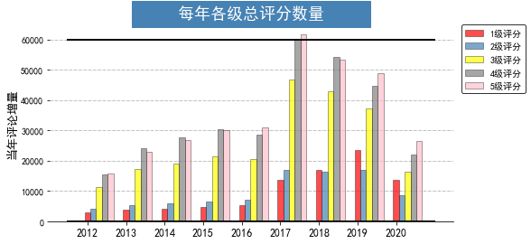

```python
colors = ['red', 'steelblue', 'yellow', 'gray', 'pink']
labels = ['1级评分', '2级评分', '3级评分', '4级评分', '5级评分']
fig = plt.figure(figsize=(8, 4))
ax = fig.add_subplot(111)

for ii, year in enumerate(sorted(data['year'].unique())):
    if ii == 0:
        for jj, rating in enumerate([1, 2, 3, 4, 5]):
            ax.bar([ii + 0.15 * jj], data.loc[(data['overall_rating']==rating) & (data['year']==year)].shape[0], width=0.15, edgecolor='black',
                   linewidth=0.5, color=colors[jj], alpha=0.7, label=labels[jj])
    else:
        for jj, rating in enumerate([1, 2, 3, 4, 5]):
            ax.bar([ii + 0.15 * jj], data.loc[(data['overall_rating']==rating) & (data['year']==year)].shape[0], width=0.15, edgecolor='black', linewidth=0.5, color=colors[jj], alpha=0.7)
ax.spines['left'].set_visible(False)
ax.spines['right'].set_visible(False)
ax.spines['top'].set_visible(False)
ax.yaxis.grid(lw=0.5, color='gray', linestyle='dashdot')
ax.set_axisbelow(True)
    # ax.xaxis.grid(linewidth=5, color='black')
ax.plot([-0.5, 9], [60000, 60000], color='black', lw=2)
ax.plot([-0.5, 9], [0, 0], color='black', lw=2)
ax.legend(loc=(1.02,0.65), edgecolor='black')
ax.set_ylabel('当年评论增量', fontsize=13)
ax.set_title('     每年各级总评分数量'+'     ', backgroundcolor='steelblue', fontsize=18, color='white', weight='bold')
ax.set_xticks(range(9))
ax.set_xticklabels([str(year) for year in range(2012, 2021)], fontsize=12)
# ax.spines['bottom'].set_visible(False)
plt.show()
```

**而2020年，员工评论量显然变少了，我们粗略的可以归因于疫情影响**

**接下来，我们从月级来分析该数据**

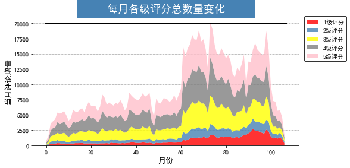

```python
cut_level = 'months'
year = sorted(data['months'].unique())
colors = ['red', 'steelblue', 'yellow','gray', 'pink']
population_by_continent = {
    '1级评分': data.loc[data['overall_rating']==1].groupby(cut_level).count()['overall_rating'],
    '2级评分': data.loc[data['overall_rating']==2].groupby(cut_level).count()['overall_rating'],
    '3级评分': data.loc[data['overall_rating']==3].groupby(cut_level).count()['overall_rating'],
    '4级评分': data.loc[data['overall_rating']==4].groupby(cut_level).count()['overall_rating'],
    '5级评分': data.loc[data['overall_rating']==5].groupby(cut_level).count()['overall_rating'],
}

fig = plt.figure(figsize=(8, 4))
ax = fig.add_subplot(111)
ax.stackplot(year, population_by_continent.values(),colors=colors,
             labels=population_by_continent.keys(), alpha=0.8)
ax.spines['left'].set_visible(False)
ax.spines['right'].set_visible(False)
ax.spines['top'].set_visible(False)
ax.yaxis.grid(lw=0.5, color='gray', linestyle='dashdot')
ax.set_axisbelow(True)
ax.legend(loc=(1.02,0.65), edgecolor='black')
ax.set_title('     每月各级评分总数量变化'+'     ', backgroundcolor='steelblue', fontsize=18, color='white', weight='bold')
ax.plot([-0.5, data['months'].unique().shape[0]], [20000, 20000], color='black', lw=2)
ax.plot([-0.5, data['months'].unique().shape[0]], [0, 0], color='black', lw=2)
ax.set_xlabel('月份', fontsize=13)
ax.set_ylabel('当月评论增量', fontsize=13)
# ax.set_xticks([ii * 12 for ii in range(9)])
# ax.set_xticklabels([str(year) for year in range(2012, 2021)], fontsize=12)
# ax.spines['bottom'].set_visible(False)
plt.show()
```

## 各公司每周的员工评论数量增加百分比

**周级粒度**

```python
'''
    每个公司最早的评论是从第几周开始的，从2012-1-1算起
'''
company_earliest = data.groupby('company_id')['weeks'].min()
```

```python
company_num_week = 0
company_ids_week = []
ealiest = 100
n = 0
for comp in company_earliest.index:
    if company_earliest.loc[comp] >= ealiest:
        n += 1
        continue
    else:
        company_ids_week.append(comp)
        company_num_week += 1
print('满足要求的公司数量, {}'.format(company_num_week))
```

```
满足要求的公司数量, 996
```

```python
'''
    这段代码有点慢，需要加速；要改为遍历，用dict来做；或者groupby 用company_id和weeks两列来做

'''
kk = 0
uni_weeks = data['weeks'].unique().shape[0]

companys = []
comp_review_count_weeks = np.zeros((company_num_week, uni_weeks))  # 合格的company数量 * 总共的年限

for comp in data.groupby('company_id'):
#     if kk % 100 == 0:
#         print(kk)
    if comp[0] in company_ids_week:
        companys.append(comp[0])
        temp = comp[1]
        for ii in range(uni_weeks):
            comp_review_count_weeks[kk, ii] += temp[temp['weeks']==ii].shape[0]
        kk += 1

sum_count_weeks = comp_review_count_weeks.sum(axis=1)
cumsum_count_weeks = comp_review_count_weeks.cumsum(axis=1)
```

### 下面可视化每个公司的评论数量随时间的累积百分比情况（截止观测最后一天累积为100%）

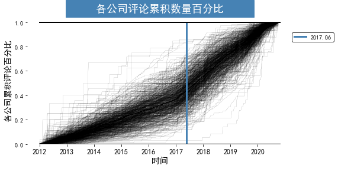

```python
fig = plt.figure(figsize=(8, 4))
ax = fig.add_subplot(111)
since_begin_num = 0
color ='black'


for ii in range(comp_review_count_weeks.shape[0]):
    #指数图
    if cumsum_count_weeks[ii, 50] < 1 and cumsum_count_weeks[ii, 100] >1 and cumsum_count_weeks[ii, 400] != sum_count_weeks[ii]:
        ax.plot(range(uni_weeks), cumsum_count_weeks[ii]/sum_count_weeks[ii], lw=0.1, alpha=0.7, color=color)
    elif cumsum_count_weeks[ii, 50] >= 1 and cumsum_count_weeks[ii, 400] != sum_count_weeks[ii]:
        ax.plot(range(uni_weeks), cumsum_count_weeks[ii]/sum_count_weeks[ii], lw=0.1, alpha=1, color=color)
ax.plot((280, 280), (0, 1), 'steelblue', lw=3, label='2017.06')

ax.spines['left'].set_visible(False)
ax.spines['right'].set_visible(False)
ax.spines['top'].set_visible(False)
# ax.yaxis.grid(lw=0.5, color='gray', linestyle='dashdot')
ax.set_axisbelow(True)
ax.legend(loc=(1.0,0.8), edgecolor='black')
ax.set_title('     各公司评论累积数量百分比'+'     ', backgroundcolor='steelblue', fontsize=18, color='white', weight='bold')
ax.plot([0, data['weeks'].unique().shape[0]], [1, 1], color='black', lw=2)
ax.plot([0, data['weeks'].unique().shape[0]], [0, 0], color='black', lw=2)
ax.set_xlabel('时间', fontsize=14)
ax.set_ylabel('各公司累积评论百分比', fontsize=14)
ax.set_ylim((0,1.05))
ax.set_xticks([ii * 52 for ii in range(9)])
ax.set_xticklabels([str(year) for year in range(2012, 2021)], fontsize=12)
ax.spines['bottom'].set_visible(False)
# ax.set_xticklabels([str(year) + '-1-1' for year in range(2012, 2021)])
plt.show()
```

**从上图可以看出，以蓝色竖线为分界线，左侧评论量增速明显低于右侧，因此，我们以该竖线之前的数据进行线性拟合回归**

# 对17年之前进行回归

```python
import statsmodels.api as sm

def lr_regression_post_before(x, y):
    x = sm.add_constant(x)
    model = sm.OLS(y, x)
    result = model.fit()
    print(result.params)
    print(result.summary())
    return result.params
```

```python
xs = []
ys = []

for jj in range(40, 286):
    for ii in range(cumsum_count_weeks.shape[0]):
        xs.append(jj)
        ys.append(cumsum_count_weeks[ii, jj]/sum_count_weeks[ii])
ys = np.array(ys)
xs = np.array(xs).reshape((-1, 1))
```

**下面进行回归并得到系数**

```python
params = lr_regression_post_before(xs, ys)
```

```
[-0.02801737  0.00165214]
                            OLS Regression Results
==============================================================================
Dep. Variable:                      y   R-squared:                       0.419
Model:                            OLS   Adj. R-squared:                  0.419
Method:                 Least Squares   F-statistic:                 1.764e+05
Date:                Mon, 21 Dec 2020   Prob (F-statistic):               0.00
Time:                        15:41:55   Log-Likelihood:             1.3713e+05
No. Observations:              245016   AIC:                        -2.742e+05
Df Residuals:                  245014   BIC:                        -2.742e+05
Df Model:                           1
Covariance Type:            nonrobust
==============================================================================
                 coef    std err          t      P>|t|      [0.025      0.975]
------------------------------------------------------------------------------
const         -0.0280      0.001    -40.166      0.000      -0.029      -0.027
x1             0.0017   3.93e-06    420.027      0.000       0.002       0.002
==============================================================================
Omnibus:                   142519.597   Durbin-Watson:                   1.952
Prob(Omnibus):                  0.000   Jarque-Bera (JB):          1564765.578
Skew:                           2.642   Prob(JB):                         0.00
Kurtosis:                      14.196   Cond. No.                         443.
==============================================================================

Warnings:
[1] Standard Errors assume that the covariance matrix of the errors is correctly specified.
```

```python
xs_ = np.linspace(0, data['weeks'].unique().shape[0], 100)
ys_ = [params[0] + params[1] * x for x in xs_]
```

```python
# mean_weeks = (cumsum_count_weeks/sum_count_weeks.reshape(-1,1)).mean(axis=0)
mean_weeks = (cumsum_count_weeks/sum_count_weeks.reshape(-1,1)).mean(axis=0)
diff_mean_weeks = np.diff(mean_weeks)
# diff_mean_weeks.shape
```

[output not shown]

**下面重新可视化评论数量变化百分比**

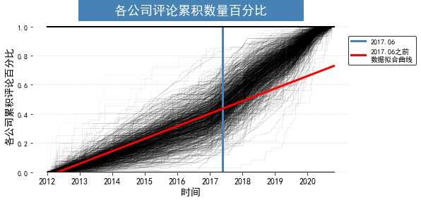

```python
fig = plt.figure(figsize=(8, 4))
ax = fig.add_subplot(111)
since_begin_num = 0
color ='black'
color_fit = 'red'
for ii in range(comp_review_count_weeks.shape[0]):
    alpha = (np.log(sum_count_weeks[ii]) + 0.1) / (0.1 + np.log(sum_count_weeks.max()))

    if cumsum_count_weeks[ii, 50] < 1 and cumsum_count_weeks[ii, 100] >1 and cumsum_count_weeks[ii, 400] != sum_count_weeks[ii]:
        ax.plot(range(uni_weeks), cumsum_count_weeks[ii]/sum_count_weeks[ii], lw=0.2, alpha=alpha, color=color)

    elif cumsum_count_weeks[ii, 50] >= 1 and cumsum_count_weeks[ii, 400] != sum_count_weeks[ii]:
        ax.plot(range(uni_weeks), cumsum_count_weeks[ii]/sum_count_weeks[ii], lw=0.2, alpha=alpha, color=color)

    #plt.plot(range(uni_weeks), cumsum_count_weeks[ii]/sum_count_weeks[ii], lw=0.4, alpha=alpha, color='red')
ax.plot((280, 280), (0, 1), 'steelblue', lw=3, label='2017.06')

ax.plot(xs_, ys_, color_fit, lw=3, label='2017.06之前\n数据拟合曲线')
ax.spines['left'].set_visible(False)
ax.spines['right'].set_visible(False)
ax.spines['top'].set_visible(False)
ax.spines['bottom'].set_visible(False)
ax.yaxis.grid(lw=0.2, color='gray', linestyle='--')
ax.set_axisbelow(True)
ax.legend(loc=(1.0,0.7), edgecolor='black')
ax.set_title('     各公司评论累积数量百分比'+'     ', backgroundcolor='steelblue', fontsize=18, color='white', weight='bold')
ax.plot([0, data['weeks'].unique().shape[0]], [1, 1], color='black', lw=2)
ax.plot([0, data['weeks'].unique().shape[0]], [0, 0], color='black', lw=2)
ax.set_xlabel('时间', fontsize=14)
ax.set_ylabel('各公司累积评论百分比', fontsize=14)
ax.set_ylim((0,1.05))
ax.set_xticks([ii * 52 for ii in range(9)])
ax.set_xticklabels([str(year) for year in range(2012, 2021)], fontsize=12)
plt.show()
```

```python
# data.to_csv('indeed_really_1900_processed.csv', index=False)
```

## 各类工作职位的员工的分布

**我们列举了开发者(developer)、经理(manager)、销售(sale)等职位**

```python
data = data.dropna(subset=['job_title'])
```

```python
job = ['Developer', 'Engineer', 'Data']

tech_num = data.loc[(data['job_title'].str.contains(job[0])) |
         (data['job_title'].str.contains(job[1])) |
         (data['job_title'].str.contains(job[2]))
        ].shape[0]
print(tech_num)
```

```
44054
```

```python
c_tech = Counter(data.loc[(data['job_title'].str.contains(job[0])) |
         (data['job_title'].str.contains(job[1])) |
         (data['job_title'].str.contains(job[2]))
        ]['overall_rating'].values)
```

```python
def job_rating(counter_dic, title):
    plt.figure(figsize=(5,6)) #调节图形大小
    labels = ['1星','2星','3星','4星','5星'] #定义标签
    sizes = [counter_dic[ii + 1] for ii in range(5)] #每块值
    colors = ['red', 'steelblue', 'yellow','gray', 'pink']
    explode = (0,0,0,0,0) #将某一块分割出来，值越大分割出的间隙越大
    patches,text1,text2 = plt.pie(sizes,
                          explode=explode,
                          labels=labels,
                          colors=colors,
                          autopct = '%3.2f%%', #数值保留固定小数位
                          shadow = False, #无阴影设置
                          startangle = 90, #逆时针起始角度设置
                          pctdistance = 0.7) #数值距圆心半径倍数距离
    for t in text1:
        t.set_size(12)
    for t in text2:
        t.set_size(12)

    #patches饼图的返回值，texts1饼图外label的文本，texts2饼图内部的文本
    # x，y轴刻度设置一致，保证饼图为圆形
    plt.legend(loc=(1,0.65), fontsize=13)
    plt.axis('equal')
    plt.title('     ' + title + '各级评分比例'+'     ', backgroundcolor='steelblue', fontsize=18, color='white', weight='bold')
    plt.show()
```

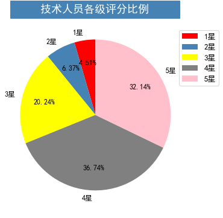

```python
job_rating(c_tech, '技术人员')
```

```python
job = 'Manager'
manager_num = data.loc[data['job_title'].str.contains(job)].shape[0]
print(manager_num)
```

```
123294
```

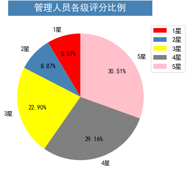

```python
c_manag = Counter(data.loc[data['job_title'].str.contains(job)]['overall_rating'].values)
job_rating(c_manag, '管理人员')
```

```python
job = ['Customer', 'Operation']
opera_num = data.loc[(data['job_title'].str.contains(job[0])) |
         (data['job_title'].str.contains(job[1]))
        ].shape[0]
print(opera_num)
```

```
82994
```

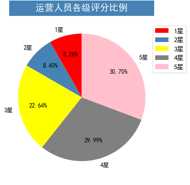

```python
c_opera = Counter(data.loc[(data['job_title'].str.contains(job[0])) |
         (data['job_title'].str.contains(job[1]))
        ]['overall_rating'].values)
job_rating(c_opera, '运营人员')
```

```python
job = 'Sale'
sale_num = data.loc[data['job_title'].str.contains(job)].shape[0]
print(sale_num)
```

```
98498
```

[figure not shown]

```python
c_sale = Counter(data.loc[data['job_title'].str.contains(job)]['overall_rating'].values)
job_rating(c_sale, '销售人员')
```

```python
job = ['Assistant', 'Intern']
intern_num = data.loc[(data['job_title'].str.contains(job[0])) |
         (data['job_title'].str.contains(job[1]))
        ].shape[0]
print(intern_num)
```

```
65792
```

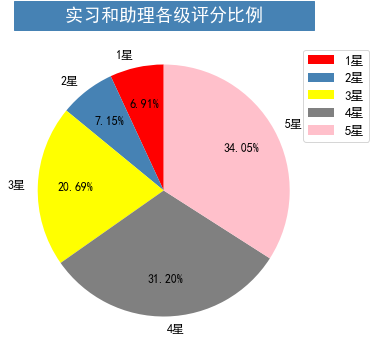

```python
c_intern = Counter(data.loc[(data['job_title'].str.contains(job[0])) |
         (data['job_title'].str.contains(job[1]))
        ]['overall_rating'].values)
job_rating(c_intern, '实习和助理')
```

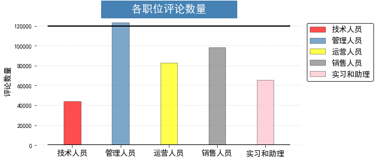

```python
position_num = [tech_num, manager_num, opera_num, sale_num, intern_num]
colors = ['red', 'steelblue', 'yellow', 'gray', 'pink']
labels = ['技术人员', '管理人员', '运营人员', '销售人员', '实习和助理']
fig = plt.figure(figsize=(8, 4))
ax = fig.add_subplot(111)

# for ii, year in enumerate(sorted(data['year'].unique())):
#     if ii == 0:
#         for jj, rating in enumerate([1, 2, 3, 4, 5]):
#             ax.bar([ii + 0.15 * jj], data.loc[(data['overall_rating']==rating) & (data['year']==year)].shape[0], width=0.15, edgecolor='black',
#                    linewidth=0.5, color=colors[jj], alpha=0.7, label=labels[jj])
#     else:
#         for jj, rating in enumerate([1, 2, 3, 4, 5]):
#             ax.bar([ii + 0.15 * jj], data.loc[(data['overall_rating']==rating) & (data['year']==year)].shape[0], width=0.15, edgecolor='black', linewidth=0.5, color=colors[jj], alpha=0.7)
for ii in range(len(position_num)):
    ax.bar([ii], position_num[ii], color=colors[ii], width=0.35, edgecolor='black', linewidth=0.5, label=labels[ii], alpha=0.7)
ax.spines['left'].set_visible(False)
ax.spines['right'].set_visible(False)
ax.spines['top'].set_visible(False)
ax.yaxis.grid(lw=0.2, color='gray', linestyle='dashdot')
ax.set_axisbelow(True)
    # ax.xaxis.grid(linewidth=5, color='black')
ax.plot([-0.5, len(position_num) - 0.5], [120000, 120000], color='black', lw=2)
ax.plot([-0.5, len(position_num) - 0.5], [0, 0], color='black', lw=2)
ax.legend(loc=(1.02,0.5), edgecolor='black', fontsize=13)
ax.set_ylabel('评论数量', fontsize=13)
ax.set_title('     各职位评论数量'+'     ', backgroundcolor='steelblue', fontsize=18, color='white', weight='bold')
ax.set_xticks(range(len(position_num)))
ax.set_xticklabels(labels, fontsize=13)
ax.spines['bottom'].set_visible(False)
plt.savefig('各职位评论数量.png', dpi=800)
plt.show()
```

```python
print('各职位类型的评论数量为')
for ii in range(len(position_num)):
    print(labels[ii], position_num[ii])
```

```
各职位类型的评论数量为
技术人员 44054
管理人员 123294
运营人员 82994
销售人员 98498
实习和助理 65792
```